# PyMC3 minimal working example and diagnostics

- Python package for Bayesian statistical modeling and Probabilistic Programming;
- Focus on advanced Markov chain Monte Carlo (MCMC) and variational inference (VI) algorithms;
- Great flexibility and direct interaction with the model.

## Useful links

- Get started with [PyMC3](https://docs.pymc.io/notebooks/getting_started)
- PyMC3 parameters [setting](https://docs.pymc.io/api/inference.html)
- PyMC3 [Github](https://github.com/pymc-devs/pymc3)
- PyMC3 [paper](https://peerj.com/articles/cs-55/)

## import X and y

- X: $23,856$ by $3$, the 2nd and 3rd gene has non-zero effect, 1.477 and 1.297. All genes are in complete LD. Fisher test p value 2.049e-09.
- y: $23,856$

```python
import os
import numpy as np, pandas as pd
cwd = os.path.expanduser("~/GIT/cnv-gene-mapping/data/deletion_simu_30_shape0.777_scale0.843")
X = pd.read_csv(f'{cwd}/block_1272_1274/deletion.genes.block30.for_simu.sample.combined.genes.block_1272_1274.gz', compression = "gzip", sep = "\t", header = None, dtype = float)
y = np.loadtxt(f'{cwd}/deletion.genes.block30.for_simu.sample.combined.y.gz', dtype=int)
```

## Spike and Slab model

Spike-and-Slab Model [link](https://www.kaggle.com/melondonkey/bayesian-spike-and-slab-in-pymc3)

```python
import pymc3 as pm
import theano.tensor as tt
import matplotlib.pyplot as plt
```

`pi_varbvs`, `mu_varbvs` and `si_varbvs` are from whole genome varbvs.

$\beta_k = (1-\pi_k)\delta_0 + \pi_k N(\mu, \sigma)$

- `pi_varbvs`: $\pi_k$ in spike-and-slab prior
- `mu_varbvs`: $\mu$ in spike-and-slab prior for β$_k$
- `si_varbvs`: $\sigma$ in spike-and-slab prior for β$_k$

```python
pi_varbvs = 0.051366009925488
mu_varbvs = 0.783230896500752
si_varbvs = 0.816999481742865
```

### Parameters

- iteration: The number of repetition;
- tune_prop: The proportion of tuning to iteration; if iteration = 10000 and tune_prop = 0.25, then tuning number is 2500. Tune means we discard the first n tuning samples; Default is 500 tuning samples.
- n_chain: The number of chains.
- n_core: The number of cores used for sampling.
- target_accept: Adapt the step size such that the average acceptance probability across the trajectories are close to target_accept. Default is 0.8. Higher values for target_accept lead to smaller step sizes.

```python
iteration = 10000
tune_prop = 0.25
seed = 1
n_chain = 10
n_core = 8
target_accept = 0.98
```

### Model

- Original:

$\beta \sim N(\mu,\sigma)$\ $\alpha \sim U(\text{lower, upper})$, where upper = log$\frac{\text{case prop}}{1-\text{case prop}}$, lower = log$\frac{\text{prevalence}}{1-\text{prevalence}}$

- Reparameterization: If we can't easily make the sampler step-size adjust to the region of space, we can adjust the region of space to make it simpler for the sampler. It can be done with a reparameterization trick. We call this the non-centered version.

$\beta_{\text{offset}} \sim N(0,1)$ \ $\beta = \mu + \sigma * \beta_{\text{offset}}$ \ $\alpha_{\text{offset}} \sim U(-1,1)$ \ $\alpha = \text{lower} + (\alpha_{\text{offset}}+1)/2*(\text{upper}-\text{lower})$

```python
def get_model(y, X, pi0 = pi_varbvs, mu = mu_varbvs, sigma = si_varbvs, prevalence = 0.05, transform = False):
    case_prop = sum(y) / y.shape[0]
    invlogit = lambda x: 1/(1 + tt.exp(-x))
    upper = np.log(case_prop / (1-case_prop))
    lower = np.log(prevalence / (1-prevalence))
    model = pm.Model()
    with model:
        xi = pm.Bernoulli('xi', pi0, shape = X.shape[1]) # inclusion probability for each variable
        # Transformed, non-centered version:
        if transform:
            # reparameterization to non-centered hierarchical model helps with sampling at hierarchical funnel
            beta_offset = pm.Normal('beta_offset', mu = 0, sd = 1, shape = X.shape[1]) # Prior for the non-zero coefficients
            alpha_offset = pm.distributions.continuous.Uniform("alpha_offset", lower = -1, upper = 1)
            beta = pm.Deterministic("beta", mu + beta_offset * sigma)
            alpha = pm.Deterministic("alpha", lower + (alpha_offset+1)/2*(upper - lower))
        # original
        else:
            beta = pm.Normal('beta', mu = mu, sd = sigma, shape = X.shape[1])
            alpha = pm.distributions.continuous.Uniform("alpha", lower = lower, upper = upper)
        p = pm.math.dot(X, xi * beta) # Deterministic function to map the stochastics to the output
        y_obs = pm.Bernoulli('y_obs', invlogit(p + alpha), observed = y)  # logistic regression
    return model
```

```python
model = get_model(y,X)
```

```python
model
```

$$ \begin{array}{rcl} \text{xi} &\sim & \text{Bernoulli}(\mathit{p}=0.051366009925488)\\\text{beta} &\sim & \text{Normal}(\mathit{mu}=0.783230896500752,~\mathit{sigma}=0.816999481742865)\\\text{alpha} &\sim & \text{Uniform}(\mathit{lower}=-2.9444389791664403,~\mathit{upper}=0.0)\\\text{y_obs} &\sim & \text{Bernoulli}(\mathit{p}=f(f(),~f(f(),~f(f(f(f(array,~f(\text{xi},~\text{beta})),~f(\text{alpha}))))))) \end{array} $$

## Sampling trace1: iteration = 10000, chain = 10

```python
with model:
    trace1 = pm.sample(draws = iteration, random_seed = seed, cores = min(n_core, n_chain), progressbar = True, chains = n_chain, tune = int(tune_prop*iteration), nuts = {"target_accept": target_accept})
```

INFO: Multiprocess sampling (10 chains in 8 jobs)

INFO: CompoundStep

INFO: >BinaryGibbsMetropolis: [xi]

INFO: >NUTS: [alpha, beta]

INFO: The number of effective samples is smaller than 25% for some parameters.

### Results

```python
pd.DataFrame({'inclusion_probability': np.apply_along_axis(np.mean, 0, trace1['xi']),
              'beta': np.apply_along_axis(np.mean, 0, np.multiply(trace1["beta"], trace1["xi"])), # posterior mean of beta
              'beta_given_inclusion': np.apply_along_axis(np.sum, 0, trace1['xi'] * trace1['beta']) / np.apply_along_axis(np.sum, 0, trace1['xi'])
             })
```

|  | inclusion_probability | beta | beta_given_inclusion |
| --- | --- | --- | --- |
| 0 | 0.43002 | 0.849084 | 1.974522 |
| 1 | 0.42651 | 0.841709 | 1.973480 |
| 2 | 0.41733 | 0.820518 | 1.966114 |

## MCMC Trace Diagnostics

- PyMC3 MCMC Trace [Diagnostics](https://eigenfoo.xyz/bayesian-modelling-cookbook/#mcmc-trace-diagnostics)
- PyMC3 diagnosing Biased Inference with [Divergences](https://docs.pymc.io/notebooks/Diagnosing_biased_Inference_with_Divergences.html)
- reference [link2](https://calogica.com/pymc3/python/2019/12/08/nfl-4thdown-attempts.html)

$\hat{R}$ (last column of the table): the Gelman–Rubin statistic; the potential scale reduction factor (PSRF); can be interpreted as a convergence diagnostic. It measures how similar the chains are. Ideally it should be close to 1.

PyMC3 includes a handy summary function that provides us with a few key estimates per variable. Aside from mean and the range covered in the hpd (highest posterior density) columns, we also want to make sure `r_hat` is ~1, while the effective sample sizes (ess) per variable are high enough to explore the posterior tails. A low number of effective samples is usually an indication of strong autocorrelation in the chain.

```python
pm.summary(trace1).round(4)
```

|  | mean | sd | hpd_3% | hpd_97% | mcse_mean | mcse_sd | ess_mean | ess_sd | ess_bulk | ess_tail | r_hat |
| --- | --- | --- | --- | --- | --- | --- | --- | --- | --- | --- | --- |
| xi[0] | 0.430 | 0.495 | 0.000 | 1.000 | 0.005 | 0.003 | 12083.0 | 12083.0 | 12083.0 | 12083.0 | 1.0 |
| xi[1] | 0.427 | 0.495 | 0.000 | 1.000 | 0.004 | 0.003 | 12507.0 | 12507.0 | 12507.0 | 12507.0 | 1.0 |
| xi[2] | 0.417 | 0.493 | 0.000 | 1.000 | 0.004 | 0.003 | 12082.0 | 12082.0 | 12082.0 | 12082.0 | 1.0 |
| beta[0] | 1.290 | 0.976 | -0.511 | 2.995 | 0.008 | 0.006 | 15593.0 | 14996.0 | 15795.0 | 43593.0 | 1.0 |
| beta[1] | 1.289 | 0.977 | -0.459 | 3.055 | 0.008 | 0.005 | 16454.0 | 16082.0 | 16757.0 | 47865.0 | 1.0 |
| beta[2] | 1.274 | 0.970 | -0.456 | 3.020 | 0.007 | 0.005 | 16777.0 | 16158.0 | 17100.0 | 48423.0 | 1.0 |
| alpha | -0.011 | 0.008 | -0.026 | -0.000 | 0.000 | 0.000 | 47456.0 | 47456.0 | 32312.0 | 23512.0 | 1.0 |

### Check the traceplot

```
array([[<matplotlib.axes._subplots.AxesSubplot object at 0x7fca119aab10>,
      dtype=object)
```

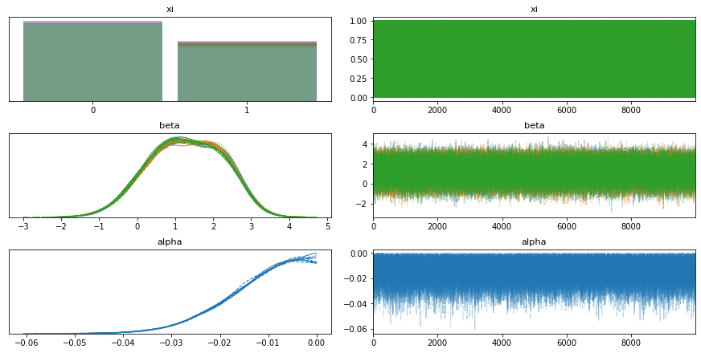

```python
pm.traceplot(trace1)
```

### Check if posteriors look reasonable

```
array([<matplotlib.axes._subplots.AxesSubplot object at 0x7fc9fc291c90>,
      dtype=object)
```

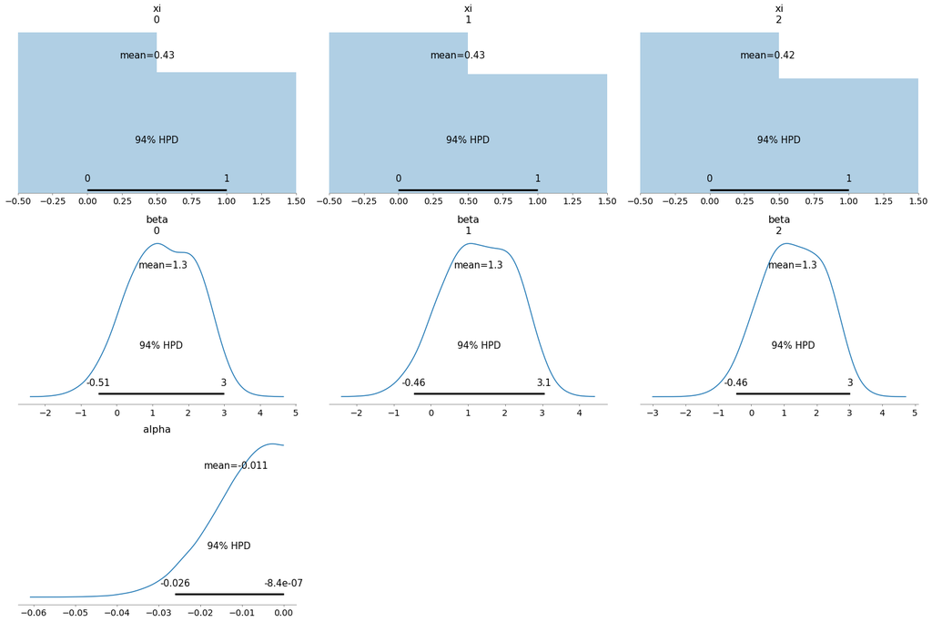

```python
pm.plot_posterior(trace1)
```

```python
def report_trace(trace):
    beta = trace['beta']
    mbeta = [np.mean(beta[:i]) for i in np.arange(1, len(beta))]
    plt.figure(figsize=(15, 4))
    plt.plot(mbeta, lw=2.5)
    plt.ylim(1, 2)
    plt.xlabel('Iteration')
    plt.ylabel('MCMC mean of beta')
    plt.title('MCMC estimation of beta')
    plt.show()
    divergent = trace['diverging']
    print('Number of Divergent %d' % divergent.nonzero()[0].size)
    divperc = divergent.nonzero()[0].size / len(trace) * 100
    print('Percentage of Divergent %.1f' % divperc)
```

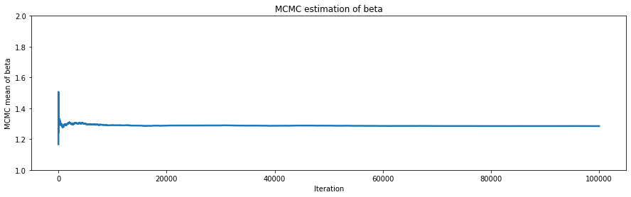

```
Number of Divergent 0
Percentage of Divergent 0.0
```

```python
report_trace(trace1)
```

**Kernel Restarting**

```python
iteration2 = 20000
tune_prop2 = 0.1
n_chain2 = 5
n_core2 = 6
```

```python
with model:
    trace2 = pm.sample(draws = iteration2, random_seed = seed, cores = max(n_core2, n_chain2), progressbar = True, chains = n_chain2, tune = int(tune_prop2*iteration2), nuts = {"target_accept": target_accept})
```

INFO: Multiprocess sampling (5 chains in 6 jobs)

INFO: CompoundStep

INFO: >BinaryGibbsMetropolis: [xi]

INFO: >NUTS: [alpha, beta]

```python
pd.DataFrame({'inclusion_probability': np.apply_along_axis(np.mean, 0, trace2['xi']),
              'beta': np.apply_along_axis(np.mean, 0, np.multiply(trace2["beta"], trace2["xi"])), # posterior mean of beta
              'beta_given_inclusion': np.apply_along_axis(np.sum, 0, trace2['xi'] * trace2['beta']) / np.apply_along_axis(np.sum, 0, trace2['xi'])
             })
```

[output not shown]

© 2016-2017 Min Qiao at [Xin He lab](http://xinhelab.org), The University of Chicago

Exported from [`dsc/20200515_pymc3_3genes_2effects.ipynb`](http://github.com/gaow/cnv-gene-mapping/blob/21cfc2ce141ac9d75add39b30c5f3404ad4abe17/dsc/20200515_pymc3_3genes_2effects.ipynb) committed by minqiao on Tue May 19 13:55:54 2020 [revision 1, 21cfc2c](http://github.com/gaow/cnv-gene-mapping/commit/21cfc2ce141ac9d75add39b30c5f3404ad4abe17)